# Diversity effects: bird community

collnell

July 5, 2016

These data are from a field experiment conducted July 2015 at the [UADY forest diversity plots near Muna, Yucatan, Mexico](http://www.treedivnet.ugent.be/ExpUADY.html). Using the tree diversity manipulation we test the predictions that  
(1) tree diversity promotes the abundance and diversity of predators (insectivorous birds) and  
(2) via effects on predators, tree diversity is correlated with greater herbivore suppression.

# Bird Observations: All Birds

### Abundance

Does **bird abundance** differ between **monoculture** and **polyculture** plots?

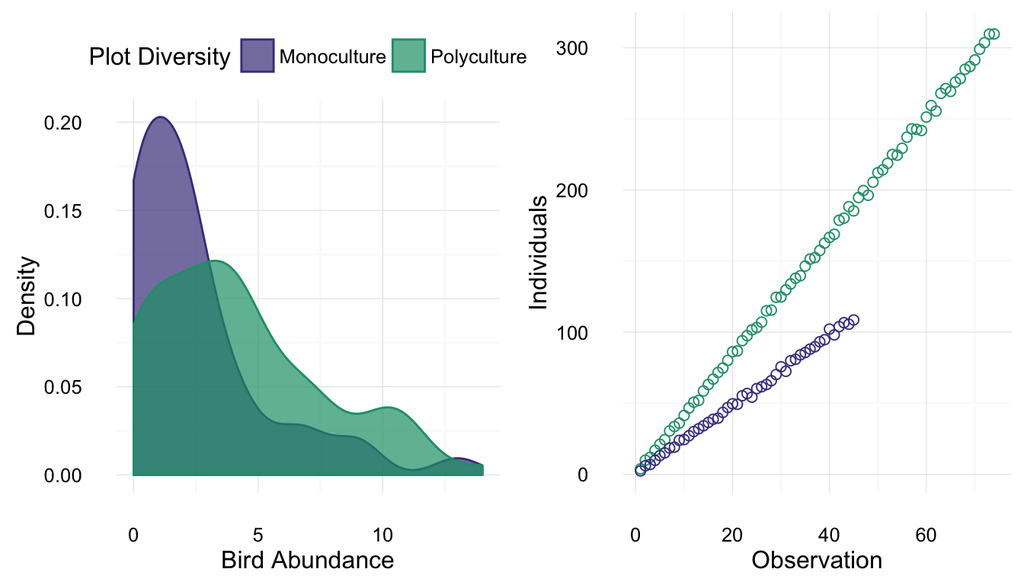

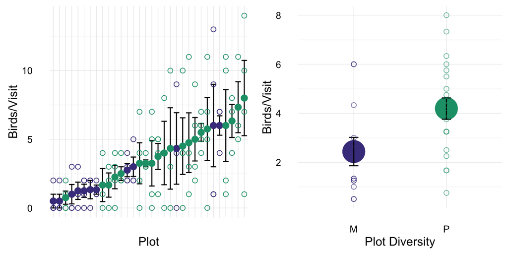

ANOVA testing for main effect of tree DIVERSITY controlling for PLOT

|  | Df | Sum Sq | Mean Sq | F value | Pr(>F) |
| --- | --- | --- | --- | --- | --- |
| **DIVERSITY** | 1 | 85.18 | 85.18 | 5.94 | 0.021 |
| **Residuals** | 30 | 429.9 | 14.33 | NA | NA |
| **Residuals1** | 87 | 776.6 | 8.93 | NA | NA |

and among **feeding guilds?**

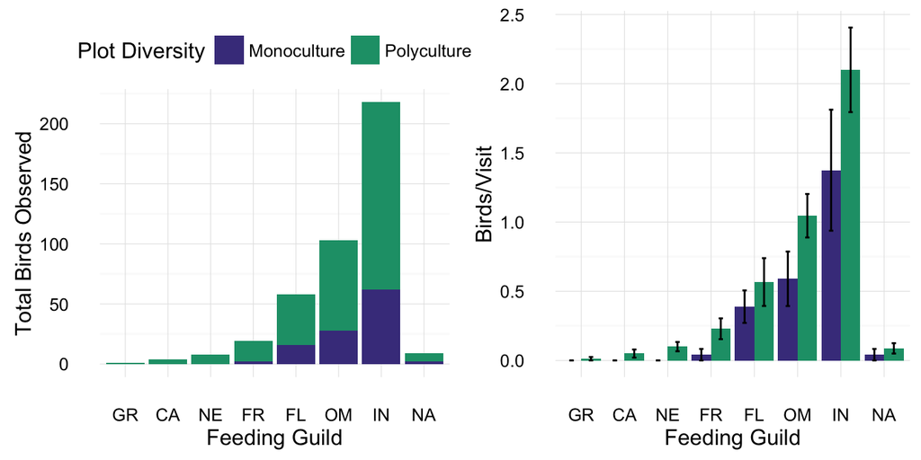

Guilds: Granivorous (GR), Carnivorous (CA), Nectivorous (NE), Frugivorous (FR), Insectivorous (FL = flycatching, IN= gleaning), Omnivorous (OM), NA = unidentified

ANOVA testing for main and interactive effects of tree DIVERSITY and FEEDING GUILD

|  | Df | Sum Sq | Mean Sq | F value | Pr(>F) |
| --- | --- | --- | --- | --- | --- |
| **DIVERSITY** | 1 | 11.48 | 11.48 | 10.34 | 0.001 |
| **feeding.guild** | 6 | 317.7 | 52.95 | 47.68 | 0 |
| **PLOT** | 1 | 0.17 | 0.17 | 0.15 | 0.7 |
| **DIVERSITY:feeding.guild** | 6 | 10.36 | 1.73 | 1.56 | 0.157 |
| **Residuals** | 818 | 908.5 | 1.11 | NA | NA |

Table: Analysis of Variance Model

### Richness

Mean richness plot/visit: 2.1512605  
Total richness: 55  
Singletons: 15

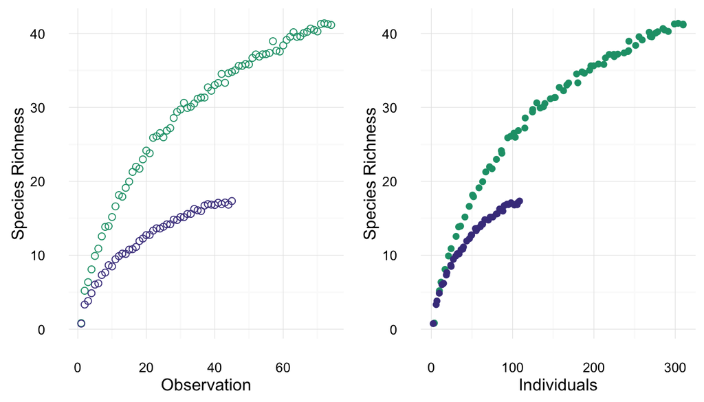

**Richness estimators:**

[output not shown]

Incidence-based extrapolation to estimate **species richness** using ‘specpool’ in ‘vegan’.

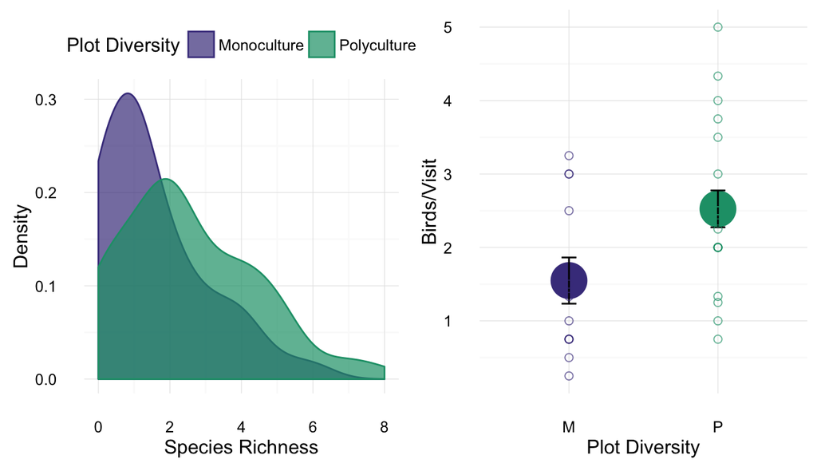

ANOVA testing for main effect of tree DIVERSITY controlling for PLOT

|  | Df | Sum Sq | Mean Sq | F value | Pr(>F) |
| --- | --- | --- | --- | --- | --- |
| **DIVERSITY** | 1 | 27.63 | 27.63 | 8.962 | 0.003369 |
| **PLOT** | 1 | 0.004178 | 0.004178 | 0.001355 | 0.9707 |
| **Residuals** | 116 | 357.6 | 3.083 | NA | NA |

Table: Analysis of Variance Model

### Taxonomy

# Bird Observations: Insectivorous Birds

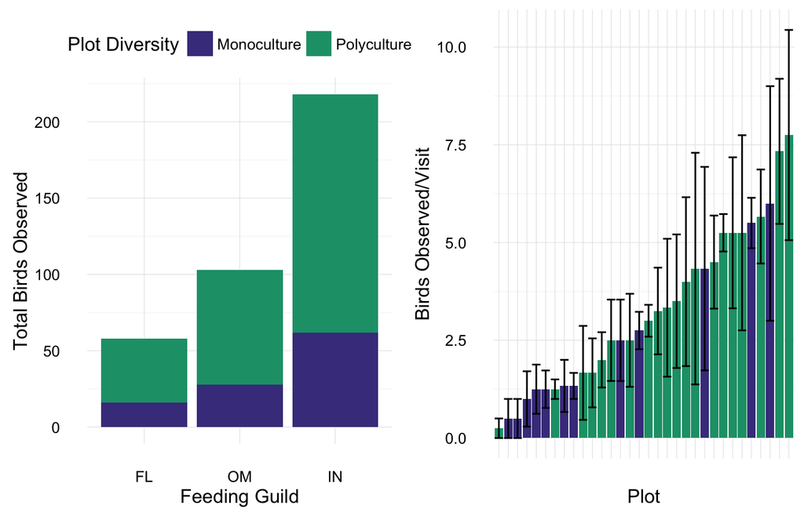

**379 observations** of **40 species** from **17 families** (Caprimulgidae, Cardinalidae, Corvidae, Cracidae, Cuculidae, Icteridae, Mimidae, Momotidae, Parulidae, Picidae, Polioptilidae, Thraupidae, Troglodytidae, Turdidae, Tyrannidae, Tytiridae, Vireonidae) and **7 orders**(, Caprimulgiformes, Coraciiformes, Cuculiformes, Galliformes, Passeriformes, Piciformes)

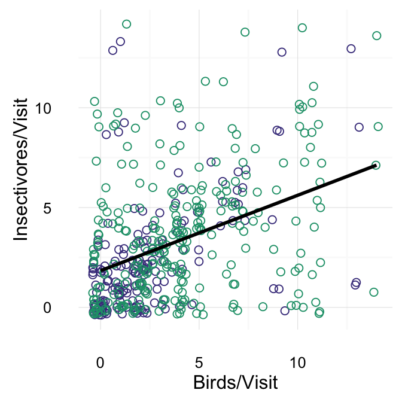

# Data

### Description

These data are from a field experiment conducted July 2015 at the [UADY forest diversity plots near Muna, Yucatan, Mexico](http://www.treedivnet.ugent.be/ExpUADY.html). Using the tree diversity manipulation we test the predictions that  
(1) tree diversity promotes the abundance and diversity of predators (insectivorous birds) and  
(2) via effects on predators, tree diversity is correlated with greater herbivore suppression.

### Data sheets

[**Bird Observations**](https://github.com/collnell/Enemies/blob/master/enemy_bird_visit.csv)  
Bird survey results from 15 minute point counts at the plot level. Each plot was visited 4 times on separate days between 0600 and 0930. These observations reflect birds actively foraging in the plots, excluding birds flying overhead or through the plot. The species of trees used by foraging birds were recorded once per individual tree. Birds that were not able to be identified definitively are recorded as species “X”, or “CH X” if a partial ID was known (CH X = chipe unknown (warbler). All bird IDs match species information on the bird list.

[**Bird List**](https://github.com/collnell/Enemies/blob/master/enemy_bird_list.csv)  
Inventory on all bird species recorded at the UADY diversity plots in January and July of 2015. Contians species codes and associated information for each ID (including feeding guild).

**Predation Experiment**  
These data are from a clay caterpillar experiment used to assay predation rates between the plots. For each experimental plot, 2 clay models were placed on opposite branches of 12 trees. Models were visited twice, 24 and 48 hours after placement, to record attack marks. Marked models were identified as either Arthropod, Bird, and Mammal and replced with a new model.

**Experimental Design**  
Data on plots used in experiment. Plot diversity, tree species, ETC